# Python for Analytics

### By: Gideon Whitehead

# Outline

- Introduction
- Why Python?
- Examples
- Conclusion

# Introduction: About Me

Classical Guitarist by Training

- BM, Cleveland Institute of Music; AD, Curtis Institute of Music
- Teach for College House Music Program at Penn
- Two Albums of Solo Classical Guitar

# Introduction: About Me

Zero Quantitative Background

- Last math class was 10th grade
- Struggled on quantitative section of GMAT

# Introduction: About Me

Learned to code **for free**

- Python in early 2015
- SQL in late 2015
- Java in 2017
- Full-stack Web Development a year ago

# Introduction: About Me

Analytics Education

- Completing MS in Business Analytics this month
- Received Clarity Certification in Ambulatory Data Model in 2016
- Completed EMC Data Science Associate certification in 2017

# Why does this matter?

# If I can do it, anyone can.

# Why Python?

### Powerful

- Full-fledged programming language
- Production ready
- There's a package for that!

# Why Python?

### Free

- Most Python packages are **totally free** (BSD, Apache 2.0, etc.)
- Many stellar IDEs are **totally free**
- Most Python packages (and even the language itself) are open source
- Many learning resources (books, tutorials, online courses, etc) are **totally free**

# Why Python?

### Easy to learn

- Simple syntax
- Readable formatting (enforced by the interpreter)
- Multitude of resources
- Stack Overflow

# Why Python?

### Growing

[figure not shown]

# Why Python?

### Popular

### Tiobe Index for April 2018

[figure not shown]

# Why Python?

### Ubiquitous

- Used in every industry (Healthcare, Finance, Academia, Astronomy, you name it...)
- Used by most major tech and analytics companies (Google, Amazon, Facebook, etc.)
- Used across technical domains (analytics, web development, etc.)

# Why Python?

Traceable

- Any error can be directly traced to the source
- Issues caused by changes in the environment can be easily found and fixed

# Why Python?

Repeatable

- Analyses can be rerun at the click of a button
- Analyses can be rerun *without* the click of a button (i.e. scheduled)
- Similar analyses can be performed on similar data with minimal code changes
- Code can be hacked and maintained long after we're all gone

# Examples: Data Visualization

### Matplotlib: Simple Scatter

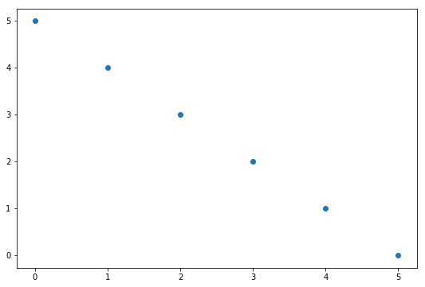

```python
import matplotlib.pyplot as plt
plt.rcParams["figure.figsize"] = (9, 6)

x = [0, 1, 2, 3, 4, 5]
y = [5, 4, 3, 2, 1, 0]

plt.scatter(x, y)
```

### Matplotlib: Smiley Scatter

```
(0, 10)
```

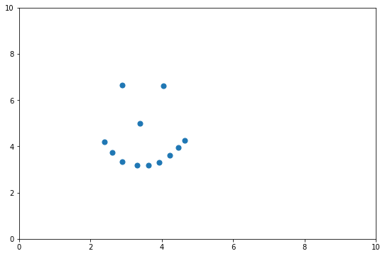

```python
x = [2.3846, 2.6154, 2.8974, 3.3077, 3.6154, 3.9231, 4.2308, 4.4615, 4.641, 2.8974, 4.0513, 3.3846]
y = [4.1851, 3.7236, 3.3389, 3.1851, 3.1851, 3.3005, 3.6082, 3.9543, 4.262, 6.6466, 6.6082, 4.9928]

plt.scatter(x, y, s=50)
plt.ylim(0, 10)
plt.xlim(0, 10)
```

### Matplotlib: Bar Chart

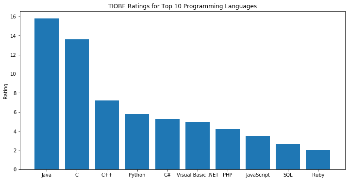

```python
plt.rcParams["figure.figsize"] = (12, 6)
y = [15.777, 13.589, 7.218, 5.803, 5.265, 4.947, 4.218, 3.492, 2.650, 2.018]
x = range(len(y))
languages = ['Java', 'C', 'C++', 'Python', 'C#', 'Visual Basic .NET', 'PHP', 'JavaScript', 'SQL', 'Ruby']

plt.bar(x, y)

plt.xticks(x, languages)
plt.ylabel("Rating")
plt.title("TIOBE Ratings for Top 10 Programming Languages")
```

### GGPlot: Datasaurus

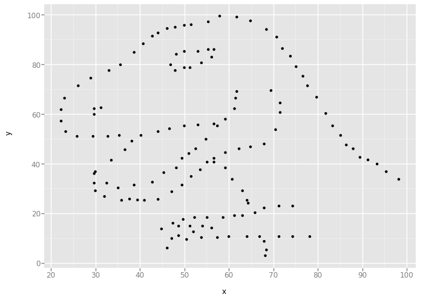

```python
import pandas as pd
from ggplot import ggplot, aes, geom_point, xlab, ylab

datasaurus = pd.read_csv("data/Datasaurus_data.csv")

ggplot(aes(x="x", y="y"), datasaurus) + geom_point()
```

### GGPlot Datasaurus: Now It's Art!

```
Put a bird on it!
```

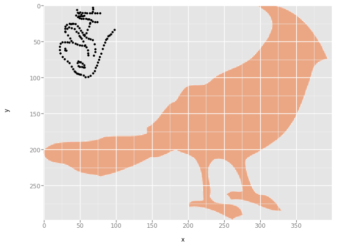

```python
from ggplot import geom_now_its_art

ggplot(aes(x="x", y="y"), datasaurus) + geom_point() + geom_now_its_art()
```

### GGPlot: Density Plot

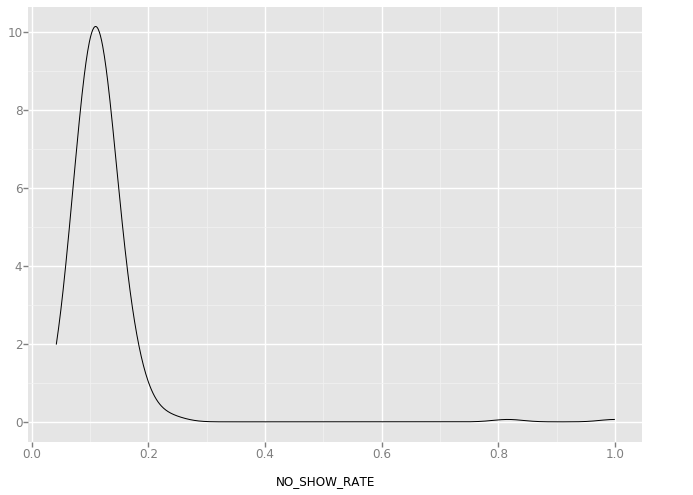

```python
from ggplot import ggplot, aes, geom_density
data = pd.read_csv("data/daily_noshow_rate.txt", sep="\t")

ggplot(aes(x="NO_SHOW_RATE"), data) + geom_density()
```

### GGPlot: Density Plot

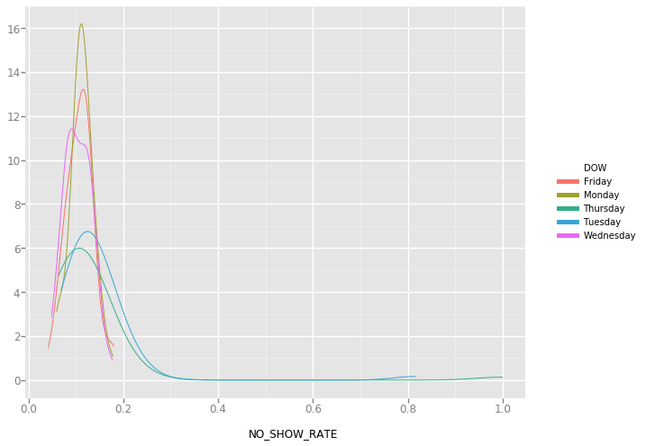

```python
ggplot(aes(x="NO_SHOW_RATE", color="DOW"), data) + geom_density()
```

```python
HTML(data.to_html(index=False))
```

| CONTACT_DATE | DOW | NO_SHOW_RATE |
| --- | --- | --- |
| 2016-10-31 00:00:00.000 | Monday | 0.178030 |
| 2017-01-09 00:00:00.000 | Monday | 0.099432 |
| 2017-05-08 00:00:00.000 | Monday | 0.111524 |
| 2017-06-12 00:00:00.000 | Monday | 0.065041 |
| 2017-03-13 00:00:00.000 | Monday | 0.112861 |
| 2017-01-16 00:00:00.000 | Monday | 0.155080 |
| 2016-08-01 00:00:00.000 | Monday | 0.136519 |
| 2017-02-20 00:00:00.000 | Monday | 0.063694 |
| 2016-08-29 00:00:00.000 | Monday | 0.120370 |
| 2016-07-11 00:00:00.000 | Monday | 0.121406 |
| 2016-11-07 00:00:00.000 | Monday | 0.116923 |
| 2017-01-30 00:00:00.000 | Monday | 0.128906 |
| 2017-03-06 00:00:00.000 | Monday | 0.122159 |
| 2017-04-03 00:00:00.000 | Monday | 0.104790 |
| 2017-06-26 00:00:00.000 | Monday | 0.098522 |
| 2016-09-12 00:00:00.000 | Monday | 0.102941 |
| 2017-02-06 00:00:00.000 | Monday | 0.125402 |
| 2016-08-22 00:00:00.000 | Monday | 0.135371 |
| 2016-11-14 00:00:00.000 | Monday | 0.109434 |
| 2016-12-19 00:00:00.000 | Monday | 0.115132 |
| 2017-05-22 00:00:00.000 | Monday | 0.134831 |
| 2017-04-10 00:00:00.000 | Monday | 0.087719 |
| 2017-05-01 00:00:00.000 | Monday | 0.112440 |
| 2016-10-03 00:00:00.000 | Monday | 0.120000 |
| 2016-09-26 00:00:00.000 | Monday | 0.140078 |
| 2016-12-05 00:00:00.000 | Monday | 0.100372 |
| 2017-02-27 00:00:00.000 | Monday | 0.063063 |
| 2016-08-08 00:00:00.000 | Monday | 0.147157 |
| 2016-10-17 00:00:00.000 | Monday | 0.106383 |
| 2017-02-13 00:00:00.000 | Monday | 0.102041 |

[output cut: 226 more lines]

# Examples: Data Cleansing

# Examples: Data Blending

# Examples: Database Interface

# Examples: Web Scraping

# Examples: Predictive Analytics

# Examples: Machine Learning

# Examples: Operations Research/Optimization

# Resources

### - [Python for Everybody](https://www.py4e.com/)

# Citations

### - [Jupyter Slides](https://medium.com/@mjspeck/presenting-code-using-jupyter-notebook-slides-a8a3c3b59d67)

### - [Python Growth Over Time](https://stackoverflow.blog/2017/09/06/incredible-growth-python/)

### - [TIOBE Index](https://www.tiobe.com/tiobe-index/)

### - [Datasuarus](http://www.thefunctionalart.com/2016/08/download-datasaurus-never-trust-summary.html)

### - [Draw My Data](http://robertgrantstats.co.uk/drawmydata.html)